“Reproducible Research Course Project 1” Prepared 2017-07-28 by Justin Goldstein using RStudio v.1.0.143 =====================================================================================

## We load the necessary files and libraries from a directory on the analyst’s laptop into R version 3.4.1.

Our main dataframe will be called *activity*, which contains three (3) columns: *steps* (total number of steps during 5-minute interval), *date*, and *interval* (number of five-minute interval).

```r
setwd("C:\\Users\\gold9629\\Documents")
activity<-read.csv("activity.csv", header=TRUE, sep=",")
library(knitr)
library(dplyr)
par(mfrow=c(1,1))
```

## We compute a **histogram** of the total number of steps taken each day.

We perform the analysis by using the “tapply” command to sum the steps taken each day. *Steps* having “NA” values are ignored during this analysis.

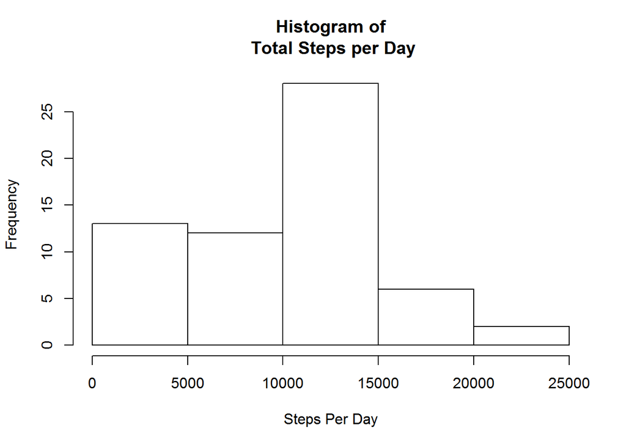

```r
#Aggregates steps by day.
totalstepsperday<-tapply(activity$steps,
activity$date, sum, na.rm=TRUE)

#Plots histogram
hist(totalstepsperday, xlab="Steps Per Day", main="Histogram of\n Total Steps per Day")
```

## We then compute the **median** and **mean** values,

respectively, for steps per day, using the *totalstepsperday* value mentioned in the chunk above.

```r
mediantotalstepsday<-median(totalstepsperday)
meantotalstepsday<-mean(totalstepsperday)
```

The median steps per day is 10395. The mean steps per day is 9354.2295082.